# Descriptive analysis

Decision on best models,for description was made based on direct estimates of AIC (Akaike, 1974) or its Monte Carlo approximation AICM (Raftery and Newwton, 2007).

As the likelihood function for *DV* was defined by:

$L_{DV} = \prod^{n}_{k=1}\pi_{ijk}^{I_{{y_{ijk}=1}}}\pi_{ijk0}^{I_{{y_{ijk}=0,5}}}\pi_{jik}^{I_{{y_{jik}=0}}}$

where $I_{()}$ represents indicator function for the results. Is necess define Y such as:

```r
Y          <- matrix(0,n,3)
Y[y==0,1]  <- 1
Y[y==.5,2] <- 1
Y[y==1,3]  <- 1
```

Each result was compared to reference from each type of model using basic or educated guesses (with naive estimation of probabilities). Basic assumptions for making those references were:

To assume summaries of historic results for wins, draws and losses from white players’ perspective. This ‘’proportional’’ model has probabilities actually estimated in original dataset and can be used to check *DV*.

```r
propto    <- (table(y)/length(y))    # proportion of results, with draws


DVeropropto   <- sum(omegag*(Y[,1]*log(propto[1])+Y[,2]*log(propto[2])+Y[,3]*log(propto[3])))    # Log Likelihood

AICDavidpropW <- -2*DVeropropto +4       #AIc
```

```
To assume a win, a draw or a loss are equiprobable, meaning basic  $\frac{1}{3}, \frac{1}{3}$ and $\frac{1}{3}$ to *DV*;
```

```r
AICEqui     <--2*sum(omegag*(Y[,1]*log(1/3)+Y[,2]*log(1/3)+Y[,3]*log(1/3)))+4   # AIC for modelos with parameters Equiproblable
```

In this table is possible see the AIC value for reference models, (AICDavidpropW and AICEqui).

$$\begin{array}{cc}
\hline
\textrm{Reference model} &\textrm{ AIC} \\
\hline
\textrm{Equiprobable} & 26610,4 \\
\textrm{Proportional} & 24129,0 \\
\hline
\end{array}$$

Using the R coda library, a diagnosis is made on the convergence of the value chain obtained by the posterior distribution.

```r
#         Loading three generated chains for each parameter
#           and the logarithm of the likelihood of the model.

c1DV1Wdg <- mcmc(read.table("cadeia.gamaA.txt"))
c2DV1Wdg <- mcmc(read.table("cadeia.gamaB.txt"))   # Three chains of rating (gama)
c3DV1Wdg <- mcmc(read.table("cadeia.gamaC.txt"))
cadeiag <- mcmc.list(c1DV1Wdg,c2DV1Wdg,c3DV1Wdg)   # Concatenating the chains


c1DV1Wdd <- mcmc(read.table("cadeia.deltaA.txt"))
c2DV1Wdd <- mcmc(read.table("cadeia.deltaB.txt"))  # Three chains of advantage white (delta).
c3DV1Wdd <- mcmc(read.table("cadeia.deltaC.txt"))
cadeiad <- mcmc.list(c1DV1Wdd,c2DV1Wdd,c3DV1Wdd)   # Concatenating the chains

c1DV1WE <- mcmc(read.table("cadeia.lambdaA.txt"))
c2DV1WE <- mcmc(read.table("cadeia.lambdaB.txt")) # Three chains of parameters Drawn (lambda).
c3DV1WE <- mcmc(read.table("cadeia.lambdaC.txt"))
cadeiaE <- mcmc.list(c1DV1WE,c2DV1WE,c3DV1WE)   # Concatenating the chains


l1DV1Wd <- read.table("cadeia.lVmA.txt")
l2DV1Wd <- read.table("cadeia.lVmB.txt")      # Three chains  the logarithm of the likelihood.
l3DV1Wd <- read.table("cadeia.lVmC.txt")
lVDV1Wdm.vec <- c(mean(l1DV1Wd$V1),mean(l2DV1Wd$V1),mean(l3DV1Wd$V1))
```

```r
lVm1WdDV <- mean(lVDV1Wdm.vec)
varlVWmDV <- var(lVDV1Wdm.vec)

#-------------------# AICM for model

AICM<--2*lVm1WdDV+2*varlVWmDV  # Log likelihook
```

$$\begin{array}{cc}
\hline
\textrm{Reference model} &\textrm{ AIC} \\
\hline
\textrm{Equiprobable} & 26610,4 \\
\textrm{Proportional} & 24129,0 \\
\hline
\textrm{Davidson Dynamic with $\delta$ } &21961,1 \\
\hline
\end{array}$$

This model derived from Davidson basic version was better than respective reference models.

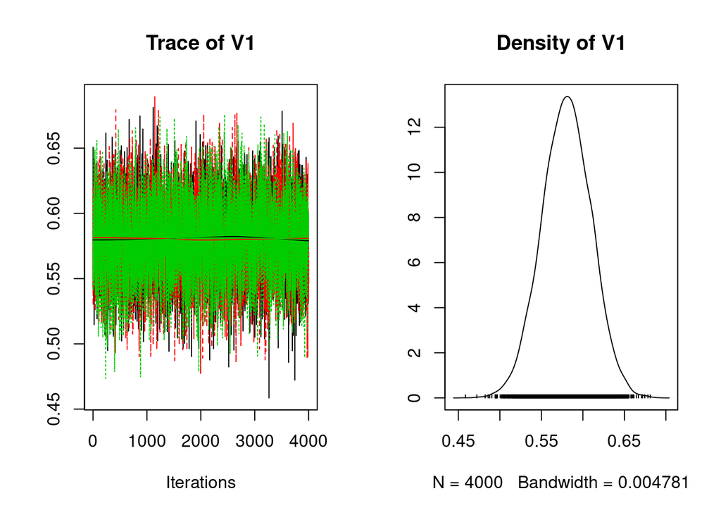

```r
plot(cadeiad)
```

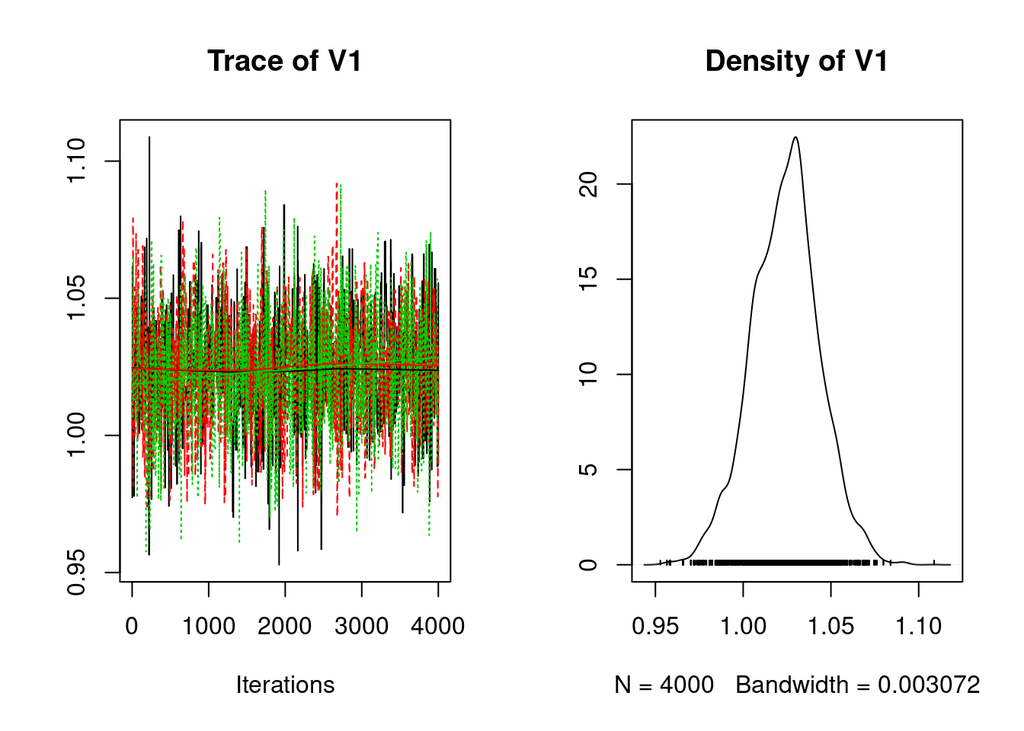

```r
plot(cadeiaE)
```

To generate the graphs, the library “gplots” was used, through function barplot2.

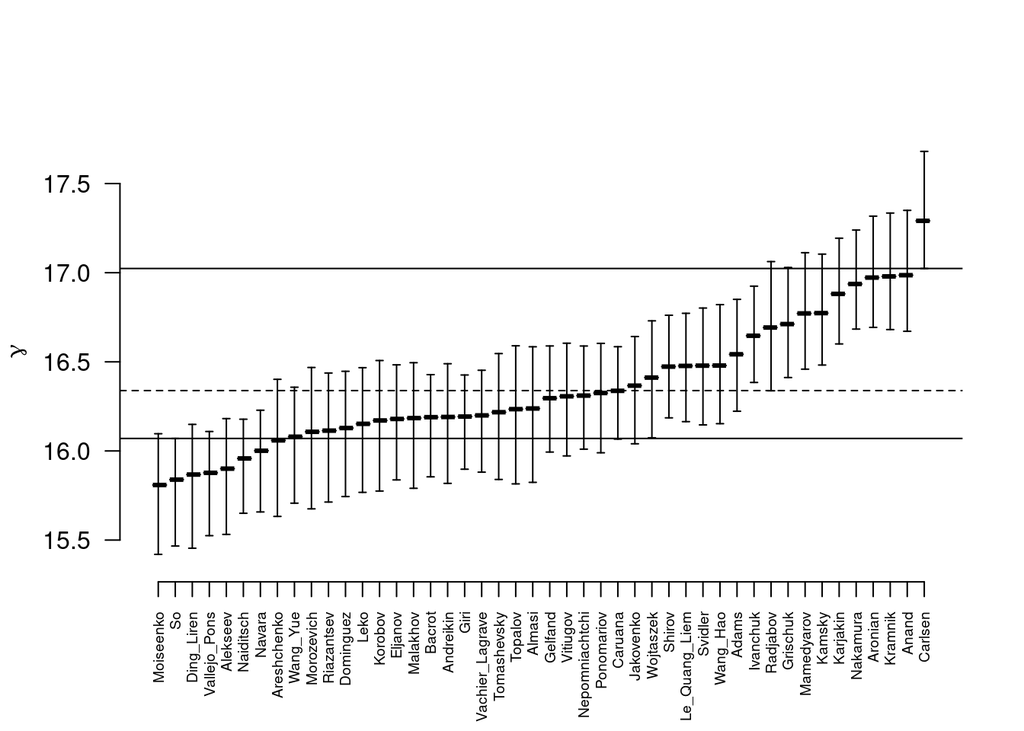

[Home page](https://danilomachadopires.github.io/Xadrez)